# Sentinel 2

## Vegetation Index calculation from Satellite Imagery

Entity: ESA

data: https://scihub.copernicus.eu/dhus/#/home

```python
import folium
import os
import numpy as np

from sentinelsat import SentinelAPI, read_geojson, geojson_to_wkt
import geopandas as gpd
import pandas as pd
import numpy as np
import matplotlib.pyplot as plt

from shapely.geometry import MultiPolygon, Polygon
import rasterio as rio
from rasterio.plot import show
import rasterio.mask
import fiona
```

Set new directory (not laptop)

```python
os.getcwd()  # Prints the current working directory
```

```
'/Users/dvf'
```

```python
os.chdir('/Volumes/TOSHIBA EXT/Stuff/S2B_MSIL2A_20190503T113329_N0211_R080_T29TNG_20190503T141928.SAFE')# Provide the new path here
```

Confirm

```python
os.getcwd()
```

```
'/Volumes/TOSHIBA EXT/Stuff/S2B_MSIL2A_20190503T113329_N0211_R080_T29TNG_20190503T141928.SAFE'
```

### Search and Download Sentinel 2 imagery using Sentinelsat API

#### Creating boundaries to narrow search

Get total bounds

```python
fp = "/Users/dvf/Documents/BGRI2011_1706/BGRI2011_1706.shp"
map_df = gpd.read_file(fp)
```

```python
map_df.total_bounds
```

```
array([  1135.8375, 213083.9588,  46002.5823, 250868.8145])
```

```python
bounding_box = map_df.envelope
dfaa = gpd.GeoDataFrame(gpd.GeoSeries(bounding_box), columns=['geometry'])
```

Union of polygons

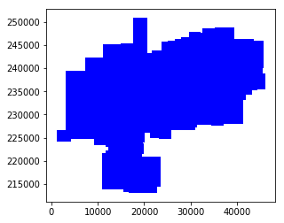

```
0    POLYGON ((37025.70579999965 227818.7677999996,...
dtype: object
```

```python
from shapely.ops import unary_union

unionboulds = gpd.GeoSeries(unary_union(dfaa["geometry"]))
unionboulds.plot(color = 'blue')
plt.show()
print(unionboulds)
```

```python
unionboulds.crs = {'init' :'epsg:3763'}
```

o plot the data on a folium map, we need to convert to a Geographic coordinate system with the wgs84 datum (EPSG: 4326). We also need to greate a GeoJSON object out of the GeoDataFrame.

```python
unionboulds = unionboulds.to_crs({'init': 'epsg:4326'})
```

```python
unionboulds.plot
```

```
<bound method GeoSeries.plot of 0    POLYGON ((-7.688165111443799 41.7189307967724,...
dtype: object>
```

### save as geojson

```python
unionboulds.to_file("unionboulds.geojson", driver="GeoJSON")
```

#### Plot a boundary in WGS 84 EPSG code 4326 on a folium slipping map

```python
m = folium.Map([41.826, -7.791], zoom_start=10)
boundsdata = unionboulds
folium.GeoJson(unionboulds).add_to(m)
m
```

[interactive chart not shown]

#### Connect to the API using a username and password

```python
user = '****' ## change this!
password = '****' ## change this!

api = SentinelAPI(user, password, 'https://scihub.copernicus.eu/dhus')

footprint = geojson_to_wkt(read_geojson('/Users/dvf/region_mx_gt_tx.geojson'))
# search by polygon
print (footprint)
```

```
POLYGON((-7.6882 41.7189,-7.6882 41.7173,-7.6888 41.7173,-7.6888 41.7172,-7.7189 41.7173,-7.7189 41.7186,-7.7416 41.7187,-7.7416 41.7182,-7.7561 41.7182,-7.7561 41.7137,-7.7615 41.7137,-7.7615 41.7082,-7.8218 41.7084,-7.8219 41.6919,-7.8547 41.6920,-7.8547 41.6935,-7.8788 41.6935,-7.8788 41.7029,-7.…
```

#### Search

```python
products = api.query(footprint,
                     date = ('20190501', '20190701'),
                     platformname = 'Sentinel-2',
                     processinglevel = 'Level-2A',
                     cloudcoverpercentage = (0,10))
```

```python
len(products)
```

```
7
```

```python
products_gdf = api.to_geodataframe(products)
products_gdf_sorted = products_gdf.sort_values(['cloudcoverpercentage'], ascending=[True])
products_gdf_sorted
```

|  | title | link | link_alternative | link_icon | summary | beginposition | endposition | ingestiondate | orbitnumber | relativeorbitnumber | ... | processingbaseline | processinglevel | producttype | platformname | size | filename | level1cpdiidentifier | identifier | uuid | geometry |
| --- | --- | --- | --- | --- | --- | --- | --- | --- | --- | --- | --- | --- | --- | --- | --- | --- | --- | --- | --- | --- | --- |
| 7660c4cc-9f50-439e-9f2e-afa25afc5689 | S2A_MSIL2A_20190525T112121_N0212_R037_T29TPG_2... | https://scihub.copernicus.eu/dhus/odata/v1/Pro... | https://scihub.copernicus.eu/dhus/odata/v1/Pro... | https://scihub.copernicus.eu/dhus/odata/v1/Pro... | Date: 2019-05-25T11:21:21.024Z, Instrument: MS... | 2019-05-25 11:21:21.024 | 2019-05-25 11:21:21.024 | 2019-05-26 07:00:03.444 | 20483 | 37 | ... | 02.12 | Level-2A | S2MSI2A | Sentinel-2 | 1.14 GB | S2A_MSIL2A_20190525T112121_N0212_R037_T29TPG_2... | S2A_OPER_MSI_L1C_TL_SGS__20190525T132011_A0204... | S2A_MSIL2A_20190525T112121_N0212_R037_T29TPG_2... | 7660c4cc-9f50-439e-9f2e-afa25afc5689 | (POLYGON ((-6.488861 41.43633638009555, -6.449... |
| 8f7359fb-63b5-4d18-8715-d76821f53c4c | S2B_MSIL2A_20190530T112119_N0212_R037_T29TNG_2... | https://scihub.copernicus.eu/dhus/odata/v1/Pro... | https://scihub.copernicus.eu/dhus/odata/v1/Pro... | https://scihub.copernicus.eu/dhus/odata/v1/Pro... | Date: 2019-05-30T11:21:19.024Z, Instrument: MS... | 2019-05-30 11:21:19.024 | 2019-05-30 11:21:19.024 | 2019-05-31 04:45:33.251 | 11646 | 37 | ... | 02.12 | Level-2A | S2MSI2A | Sentinel-2 | 1.10 GB | S2B_MSIL2A_20190530T112119_N0212_R037_T29TNG_2... | S2B_OPER_MSI_L1C_TL_EPAE_20190530T124016_A0116... | S2B_MSIL2A_20190530T112119_N0212_R037_T29TNG_2... | 8f7359fb-63b5-4d18-8715-d76821f53c4c | (POLYGON ((-7.6855774 41.45624189757688, -7.66... |
| b9e63db9-939f-4d3b-a9ee-1e0d8fd4dbfa | S2A_MSIL2A_20190528T113321_N0212_R080_T29TNG_2... | https://scihub.copernicus.eu/dhus/odata/v1/Pro... | https://scihub.copernicus.eu/dhus/odata/v1/Pro... | https://scihub.copernicus.eu/dhus/odata/v1/Pro... | Date: 2019-05-28T11:33:21.024Z, Instrument: MS... | 2019-05-28 11:33:21.024 | 2019-05-28 11:33:21.024 | 2019-05-28 23:58:07.444 | 20526 | 80 | ... | 02.12 | Level-2A | S2MSI2A | Sentinel-2 | 1.02 GB | S2A_MSIL2A_20190528T113321_N0212_R080_T29TNG_2... | S2A_OPER_MSI_L1C_TL_MPS__20190528T134029_A0205... | S2A_MSIL2A_20190528T113321_N0212_R080_T29TNG_2... | b9e63db9-939f-4d3b-a9ee-1e0d8fd4dbfa | (POLYGON ((-8.021606 41.45816151054315, -7.984... |
| 894a5e35-e864-4a22-a170-6196f16c0a05 | S2A_MSIL2A_20190525T112121_N0212_R037_T29TNG_2... | https://scihub.copernicus.eu/dhus/odata/v1/Pro... | https://scihub.copernicus.eu/dhus/odata/v1/Pro... | https://scihub.copernicus.eu/dhus/odata/v1/Pro... | Date: 2019-05-25T11:21:21.024Z, Instrument: MS... | 2019-05-25 11:21:21.024 | 2019-05-25 11:21:21.024 | 2019-05-26 07:01:01.878 | 20483 | 37 | ... | 02.12 | Level-2A | S2MSI2A | Sentinel-2 | 1.11 GB | S2A_MSIL2A_20190525T112121_N0212_R037_T29TNG_2... | S2A_OPER_MSI_L1C_TL_SGS__20190525T132011_A0204... | S2A_MSIL2A_20190525T112121_N0212_R037_T29TNG_2... | 894a5e35-e864-4a22-a170-6196f16c0a05 | (POLYGON ((-7.6855774 41.45624189757688, -7.66... |
| 2511bcd5-2fe3-4505-a084-4d7054bbed21 | S2B_MSIL2A_20190530T112119_N0212_R037_T29TPG_2... | https://scihub.copernicus.eu/dhus/odata/v1/Pro... | https://scihub.copernicus.eu/dhus/odata/v1/Pro... | https://scihub.copernicus.eu/dhus/odata/v1/Pro... | Date: 2019-05-30T11:21:19.024Z, Instrument: MS... | 2019-05-30 11:21:19.024 | 2019-05-30 11:21:19.024 | 2019-05-31 04:59:11.930 | 11646 | 37 | ... | 02.12 | Level-2A | S2MSI2A | Sentinel-2 | 1.14 GB | S2B_MSIL2A_20190530T112119_N0212_R037_T29TPG_2... | S2B_OPER_MSI_L1C_TL_EPAE_20190530T124016_A0116... | S2B_MSIL2A_20190530T112119_N0212_R037_T29TPG_2... | 2511bcd5-2fe3-4505-a084-4d7054bbed21 | (POLYGON ((-6.488861 41.43633638009555, -6.449... |
| 95073365-ae2c-4bea-a488-1e3be5ebbeff | S2B_MSIL2A_20190513T113329_N0212_R080_T29TNG_2... | https://scihub.copernicus.eu/dhus/odata/v1/Pro... | https://scihub.copernicus.eu/dhus/odata/v1/Pro... | https://scihub.copernicus.eu/dhus/odata/v1/Pro... | Date: 2019-05-13T11:33:29.024Z, Instrument: MS... | 2019-05-13 11:33:29.024 | 2019-05-13 11:33:29.024 | 2019-05-13 23:12:10.137 | 11403 | 80 | ... | 02.12 | Level-2A | S2MSI2A | Sentinel-2 | 1000.41 MB | S2B_MSIL2A_20190513T113329_N0212_R080_T29TNG_2... | S2B_OPER_MSI_L1C_TL_EPAE_20190513T134430_A0114... | S2B_MSIL2A_20190513T113329_N0212_R080_T29TNG_2... | 95073365-ae2c-4bea-a488-1e3be5ebbeff | (POLYGON ((-8.034943 41.45823759629042, -8.025... |
| ec5df91d-7127-443c-ba61-00022d35e572 | S2B_MSIL2A_20190503T113329_N0211_R080_T29TNG_2... | https://scihub.copernicus.eu/dhus/odata/v1/Pro... | https://scihub.copernicus.eu/dhus/odata/v1/Pro... | https://scihub.copernicus.eu/dhus/odata/v1/Pro... | Date: 2019-05-03T11:33:29.024Z, Instrument: MS... | 2019-05-03 11:33:29.024 | 2019-05-03 11:33:29.024 | 2019-05-03 19:27:48.139 | 11260 | 80 | ... | 02.11 | Level-2A | S2MSI2A | Sentinel-2 | 1.00 GB | S2B_MSIL2A_20190503T113329_N0211_R080_T29TNG_2... | S2B_OPER_MSI_L1C_TL_SGS__20190503T133247_A0112... | S2B_MSIL2A_20190503T113329_N0211_R080_T29TNG_2... | ec5df91d-7127-443c-ba61-00022d35e572 | (POLYGON ((-8.033478000000001 41.4582292630517... |

7 rows × 35 columns

```python
products_gdf_sorted['identifier']
```

```
7660c4cc-9f50-439e-9f2e-afa25afc5689    S2A_MSIL2A_20190525T112121_N0212_R037_T29TPG_2...
8f7359fb-63b5-4d18-8715-d76821f53c4c    S2B_MSIL2A_20190530T112119_N0212_R037_T29TNG_2...
b9e63db9-939f-4d3b-a9ee-1e0d8fd4dbfa    S2A_MSIL2A_20190528T113321_N0212_R080_T29TNG_2...
894a5e35-e864-4a22-a170-6196f16c0a05    S2A_MSIL2A_20190525T112121_N0212_R037_T29TNG_2...
2511bcd5-2fe3-4505-a084-4d7054bbed21    S2B_MSIL2A_20190530T112119_N0212_R037_T29TPG_2...
95073365-ae2c-4bea-a488-1e3be5ebbeff    S2B_MSIL2A_20190513T113329_N0212_R080_T29TNG_2...
ec5df91d-7127-443c-ba61-00022d35e572    S2B_MSIL2A_20190503T113329_N0211_R080_T29TNG_2...
Name: identifier, dtype: object
```

Plot the table as a GeoPandas dataframe, based on the uuid field

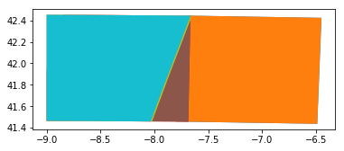

```python
areas = api.to_geodataframe(products)
areas.plot(column='uuid', cmap=None)
```

Label these polygons

```
2511bcd5-2fe3-4505-a084-4d7054bbed21    Annotation(-7.13133, 41.9424, '2511bcd5-2fe3-4...
7660c4cc-9f50-439e-9f2e-afa25afc5689    Annotation(-7.13133, 41.9424, '7660c4cc-9f50-4...
894a5e35-e864-4a22-a170-6196f16c0a05    Annotation(-8.31628, 41.9444, '894a5e35-e864-4...
8f7359fb-63b5-4d18-8715-d76821f53c4c    Annotation(-8.31915, 41.9455, '8f7359fb-63b5-4...
95073365-ae2c-4bea-a488-1e3be5ebbeff    Annotation(-8.42071, 41.9815, '95073365-ae2c-4...
b9e63db9-939f-4d3b-a9ee-1e0d8fd4dbfa    Annotation(-8.41419, 41.981, 'b9e63db9-939f-4d...
ec5df91d-7127-443c-ba61-00022d35e572    Annotation(-8.42018, 41.9815, 'ec5df91d-7127-4...
dtype: object
```

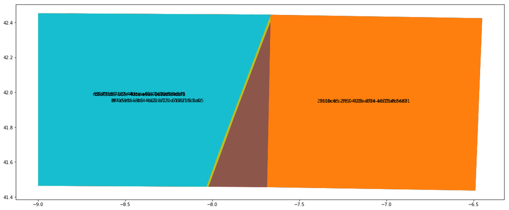

```python
ax = areas.plot(column='uuid', cmap=None, figsize=(20, 20), label='uuid')
areas.apply(lambda x: ax.annotate(s=x.uuid, xy=x.geometry.centroid.coords[0], ha='center'),axis=1)
```

##### Inspect vs defined bounds

use geopandas to check which data download

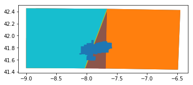

```python
f, ax = plt.subplots(1)
areas.plot(ax=ax,column='uuid',cmap=None,)
unionboulds.plot(ax=ax)
plt.show()
```

```python
api.get_product_odata('7660c4cc-9f50-439e-9f2e-afa25afc5689')
```

```
{'Creation Date': datetime.datetime(2019, 5, 26, 9, 0, 57, 340000),
 'Ingestion Date': datetime.datetime(2019, 5, 26, 7, 0, 3, 444000),
 'Online': True,
 'date': datetime.datetime(2019, 5, 25, 11, 21, 21, 24000),
 'footprint': 'POLYGON((-7.7839966 42.44624086265282,-6.4497986 42.42431413705452,-6.488861 41.43633638009555,-7.802643 41.457520191909595,-7.7839966 42.44624086265282))',
 'id': '7660c4cc-9f50-439e-9f2e-afa25afc5689',
 'md5': '9DA54B26418423714B2C37DC31FBEE36',
 'size': 1225281722,
 'title': 'S2A_MSIL2A_20190525T112121_N0212_R037_T29TPG_20190525T193310',
 'url': "https://scihub.copernicus.eu/dhus/odata/v1/Products('7660c4cc-9f50-439e-9f2e-afa25afc5689')/$value"}
```

Download the data

```python
#api.download("7660c4cc-9f50-439e-9f2e-afa25afc5689", directory_path= "/TOSHIBA EXT/" )
```

```python
# Open Bands 4, 3 and 2 with Rasterio
#R10 = '/Users/dvf/Desktop/S2B_MSIL2A_20190503T113329_N0211_R080_T29TNG_20190503T141928.SAFE/GRANULE/L2A_T29TNG_A011260_20190503T113326/IMG_DATA/R10m'
R10 = '/Volumes/TOSHIBA EXT/Stuff/S2B_MSIL2A_20190503T113329_N0211_R080_T29TNG_20190503T141928.SAFE/GRANULE/L2A_T29TNG_A011260_20190503T113326/IMG_DATA/R10m'

b4 = rio.open(R10+'/T29TNG_20190503T113329_B04_10m.jp2')
b3 = rio.open(R10+'/T29TNG_20190503T113329_B03_10m.jp2')
b2 = rio.open(R10+'/T29TNG_20190503T113329_B02_10m.jp2')
```

```python
b4.count, b4.width, b4.height
```

```
(1, 10980, 10980)
```

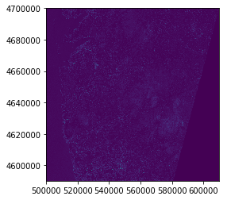

```python
fig, ax = plt.subplots(1)
show(b4, ax=ax)
plt.show()
```

```python
image_file ='/Volumes/TOSHIBA EXT/Stuff/S2B_MSIL2A_20190503T113329_N0211_R080_T29TNG_20190503T141928.SAFE/GRANULE/L2A_T29TNG_A011260_20190503T113326/IMG_DATA/R10m/T29TNG_20190503T113329_TCI_10m.jp2'
sat_data = rasterio.open(image_file)
```

```python
width_in_projected_units = sat_data.bounds.right - sat_data.bounds.left
height_in_projected_units = sat_data.bounds.top - sat_data.bounds.bottom
print("Width: {}, Height: {}".format(width_in_projected_units, height_in_projected_units))
```

```
Width: 109800.0, Height: 109800.0
```

```python
print("Rows: {}, Columns: {}".format(sat_data.height, sat_data.width))
```

[output not shown]

```python
# Upper left pixel
row_min = 0
col_min = 0

# Lower right pixel.  Rows and columns are zero indexing.
row_max = sat_data.height - 1
col_max = sat_data.width - 1

# Transform coordinates with the dataset's affine transformation.
topleft = sat_data.transform * (row_min, col_min)
botright = sat_data.transform * (row_max, col_max)

print("Top left corner coordinates: {}".format(topleft))
print("Bottom right corner coordinates: {}".format(botright))
```

```
Top left corner coordinates: (499980.0, 4700040.0)
Bottom right corner coordinates: (609770.0, 4590250.0)
```

```python
print(sat_data.count)
# sequence of band indexes
print(sat_data.indexes)
```

```
3
(1, 2, 3)
```

```python
# Load the 4 bands into 2d arrays
b, g, r = sat_data.read()
```

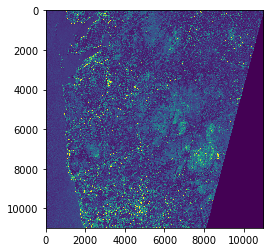

```python
# Displaying the blue band.
fig = plt.imshow(b)
plt.show()
```

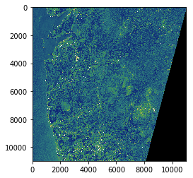

```python
# Displaying the green band.
fig = plt.imshow(g)
fig.set_cmap('gist_earth')
plt.show()
```

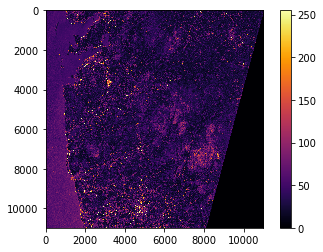

```python
# Displaying the red band.

fig = plt.imshow(r)
fig.set_cmap('inferno')
plt.colorbar()
plt.show()
```

##### NDVI

One of the most widely used index to measure vegetation is the Normalized Difference Vegetation Index (NDVI). the NDVI values range from +1.0 to -1.0. It was developed by NASA scientist Compton Tucker in 1977 and is derived from satellite imagery.

Calculating NDVI for our Area of Interest Loading the necessary libraries

```python
filename ='/Volumes/TOSHIBA EXT/Stuff/S2B_MSIL2A_20190503T113329_N0211_R080_T29TNG_20190503T141928.SAFE/GRANULE/L2A_T29TNG_A011260_20190503T113326/IMG_DATA/R10m/T29TNG_20190503T113329_TCI_10m.jp2'

with rasterio.open(filename) as src:
    band_red = src.read(2)
with rasterio.open(filename) as src:
    band_nir = src.read(3)
```

Calculating NDVI

```python
import numpy
import rasterio as rio

# Do not display error when divided by zero
numpy.seterr(divide='ignore', invalid='ignore')

# Open b4 and b8

b4 = rio.open('/Users/dvf/Desktop/S2B_MSIL2A_20190503T113329_N0211_R080_T29TNG_20190503T141928.SAFE/GRANULE/L2A_T29TNG_A011260_20190503T113326/IMG_DATA/R10m/T29TNG_20190503T113329_B04_10m.jp2')
b8 = rio.open('/Users/dvf/Desktop/S2B_MSIL2A_20190503T113329_N0211_R080_T29TNG_20190503T141928.SAFE/GRANULE/L2A_T29TNG_A011260_20190503T113326/IMG_DATA/R10m/T29TNG_20190503T113329_B08_10m.jp2')


# read Red(b4) and NIR(b8) as arrays
red = b4.read()
nir = b8.read()

# Calculate ndvi
ndvi = (nir.astype(float)-red.astype(float))/(nir+red)
```

```python
ndvi
```

```
array([[[ 0.02180685, -0.07120743,  0.01030928, ...,  0.79647851,
          0.78973105,  0.84136771],
        [ 0.01127214, -0.04374057,  0.01769912, ...,  0.84090216,
          0.83917149,  0.84441733],
        [-0.0178282 , -0.04047976, -0.01395349, ...,  0.88831836,
          0.91112338,  0.856974  ],
        ...,
        [ 0.2357513 ,  0.18756937,  0.14893617, ...,         nan,
                 nan,         nan],
        [-0.00182482, -0.05762712, -0.05511811, ...,         nan,
                 nan,         nan],
        [-0.12053571, -0.09963986, -0.09927361, ...,         nan,
                 nan,         nan]]])
```

Checking the range of NDVI values(excluding NaN) Let's print the minimum and maximum values in our calculated ndvi. Because we're using the NDVI formula to normalize the input bands, we know that our expected values should fall within -1.0 to +1.0.

```python
print(numpy.nanmin(ndvi))
print(numpy.nanmax(ndvi))
```

```
-1.0
1.0
```

#### unsupervised classification

```python
from sklearn import cluster
from osgeo import gdal, gdal_array

# Tell GDAL to throw Python exceptions, and register all drivers
gdal.UseExceptions()
gdal.AllRegister()

# Read in raster image
img_ds = gdal.Open('/Users/dvf/Desktop/S2B_MSIL2A_20190503T113329_N0211_R080_T29TNG_20190503T141928.SAFE/GRANULE/L2A_T29TNG_A011260_20190503T113326/IMG_DATA/R10m/T29TNG_20190503T113329_TCI_10m.jp2'
, gdal.GA_ReadOnly)


band = img_ds.GetRasterBand(2)

img = band.ReadAsArray()
print (img.shape)

X = img.reshape((-1,1))
print (X.shape)


k_means = cluster.KMeans(n_clusters=8)
k_means.fit(X)

X_cluster = k_means.labels_
X_cluster = X_cluster.reshape(img.shape)

print (len(X_cluster))
```

[output not shown]